# Acute effect workshop time series analysis example

Chen Chen

21 October, 2022

Here I am showing an example of time-series analysis looking at the acute effect of daily average fine particulate matter ($PM_{2.5}$) on incident rate of daily cardiovascular hospitalization among those age 65 and up in 192 California ZIP-Code Tabulation Areas (ZCTA) from 2006 to 2013. In this example, daily temperature and daily dew point temperature are considered as potential confounders.

```r
library(knitr) ## for Rmarkdonw functions
library(data.table) ## for easy handling of data
library(splines) ## for "ns" function
# remotes::install_github("rdpeng/tlnise") ## installation of tlnise package. There are other packages that conducts Bayesian hierarchical model as well (R2OpenBUGS).
library(tlnise) ## for Bayesian hierarchical model pooling
library(mvmeta) ## for random-effect meta-regression pooling
library(ggplot2) ## for plotting
```

## Quick look at the data (one ZCTA)

Due to privacy concern, I could not show the real data but here is a fake example from one random ZCTA. Daily temperature and daily dew point temperature are potential time-varying confounders for $PM_{2.5}$~cardiovascular hospitalization relationship.

*date*: corresponding date of the row.  
*zcta*: ZIP-Code Tabulation Areas for the data. Forced to be “66666” for privacy concern.  
*pop*: annual average population 65 and older in ZCTA 66666.  
*cardio_disease*: number of cardiovascular disease hospitalizations among those 65 and older in ZCTA 66666. Forced to be 0 for privacy concern.  
*mean_pm25*: daily average $PM_{2.5}$ concentration ($\mu g/m^3$) in ZCTA 66666.  
*tmpt*: daily average temperature (Celsius degree) in ZCTA 66666.  
*dptp*: daily average dew point temperature (Celsius degree) in ZCTA 66666.

```r
print(head(dt))
```

```
##          date  zcta  pop cardio_disease mean_pm25   tmpt dptp
## 1: 2006-01-01 66666 3999              0  5.292165  9.845 7.34
## 2: 2006-01-02 66666 3999              0  6.919871  8.911 7.49
## 3: 2006-01-03 66666 3999              0 10.252720  9.305 6.98
## 4: 2006-01-04 66666 3999              0  9.627160 10.525 7.34
## 5: 2006-01-05 66666 3999              0 18.365769 11.797 6.97
## 6: 2006-01-06 66666 3999              0 20.075196 10.573 7.15
```

### Cleaning of dataset and add necessary variables

```r
## create new time variable & day of week
dt <- dt[order(dt$date), ]
dt$day <- seq(1:length(unique(dt$date)))
dt$dow <- as.factor(format(dt$date, "%w")) #reference category is Sunday

## create moving average of previous three-day temperature/dew point temperature
dt[, rmtmpt:= shift(frollapply(dt$tmpt, n=3, FUN=mean, fill=NA, align="right"), n = 1, fill = NA, type = "lag")]
dt[, rmdptp := shift(frollapply(dt$dptp, n=3, FUN=mean, fill=NA, align="right"), n = 1, fill = NA, type = "lag")]
```

Last, I evaluated data missing in the dataset since only rows with complete data will be included in the model and I don’t want any pattern in the data missing. The data missing in this dataset is minimal and seems to be related to $PM_{2.5}$ dataset only so we will ignore them.

```r
print(head(dt))
```

```
##          date  zcta  pop cardio_disease mean_pm25   tmpt dptp day dow    rmtmpt
## 1: 2006-01-01 66666 3999              0  5.292165  9.845 7.34   1   0        NA
## 2: 2006-01-02 66666 3999              0  6.919871  8.911 7.49   2   1        NA
## 3: 2006-01-03 66666 3999              0 10.252720  9.305 6.98   3   2        NA
## 4: 2006-01-04 66666 3999              0  9.627160 10.525 7.34   4   3  9.353667
## 5: 2006-01-05 66666 3999              0 18.365769 11.797 6.97   5   4  9.580334
## 6: 2006-01-06 66666 3999              0 20.075196 10.573 7.15   6   5 10.542334
##      rmdptp
## 1:       NA
## 2:       NA
## 3:       NA
## 4: 7.270000
## 5: 7.270000
## 6: 7.096667
```

```r
summary(dt) ## analysis will only be done in complete dataset so it's important to know where the missing data are
```

```
##       date                 zcta            pop       cardio_disease
##  Min.   :2006-01-01   Min.   :66666   Min.   :3999   Min.   :0
##  1st Qu.:2008-01-01   1st Qu.:66666   1st Qu.:3999   1st Qu.:0
##  Median :2009-12-31   Median :66666   Median :3999   Median :0
##  Mean   :2009-12-31   Mean   :66666   Mean   :3999   Mean   :0
##  3rd Qu.:2011-12-31   3rd Qu.:66666   3rd Qu.:3999   3rd Qu.:0
##  Max.   :2013-12-31   Max.   :66666   Max.   :3999   Max.   :0
##
##    mean_pm25           tmpt             dptp              day         dow
##  Min.   : 3.339   Min.   : 0.351   Min.   :-14.030   Min.   :   1.0   0:418
##  1st Qu.: 6.739   1st Qu.:10.464   1st Qu.:  2.612   1st Qu.: 731.2   1:418
##  Median : 8.544   Median :16.230   Median :  6.565   Median :1461.5   2:418
##  Mean   :10.412   Mean   :16.625   Mean   :  6.025   Mean   :1461.5   3:417
##  3rd Qu.:11.880   3rd Qu.:23.202   3rd Qu.:  9.900   3rd Qu.:2191.8   4:417
##  Max.   :68.813   Max.   :34.414   Max.   : 18.440   Max.   :2922.0   5:417
##  NA's   :8                                                            6:417
##      rmtmpt            rmdptp
##  Min.   : 0.5647   Min.   :-11.940
##  1st Qu.:10.5817   1st Qu.:  2.713
##  Median :16.1110   Median :  6.433
##  Mean   :16.6321   Mean   :  6.030
##  3rd Qu.:23.2553   3rd Qu.:  9.640
##  Max.   :33.9873   Max.   : 17.283
##  NA's   :3         NA's   :3
```

```r
dt$date[is.na(dt$mean_pm25)] ##
```

```
## [1] "2006-12-31" "2007-12-31" "2008-12-31" "2009-12-31" "2010-12-31"
## [6] "2011-12-31" "2012-12-31" "2013-12-31"
```

### Data trajectory

It is important to have a look at the temporal trajectory of our data for any unusual patterns (e.g., sudden changes). This should be done for all geographical units (ZCTAs) included in the analysis. AS we can see, there is clear seasonal trends and a likely wildfire period in 2008.

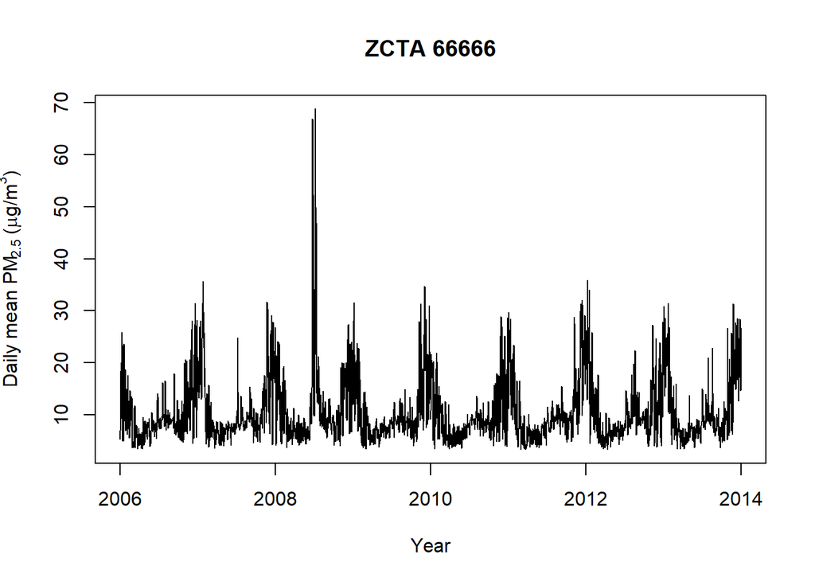

```r
print(plot(dt$date, dt$mean_pm25, type="l", main="ZCTA 66666", xlab = "Year", ylab = expression("Daily mean PM"[2.5]~"("*mu*"g/m"^3*")")))
```

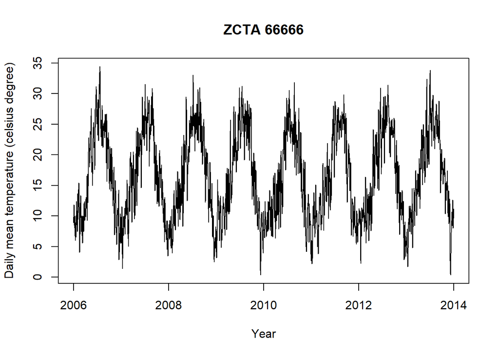

```r
print(plot(dt$date, dt$tmpt, type="l", main="ZCTA 66666", xlab = "Year", ylab = "Daily mean temperature (celsius degree)"))
```

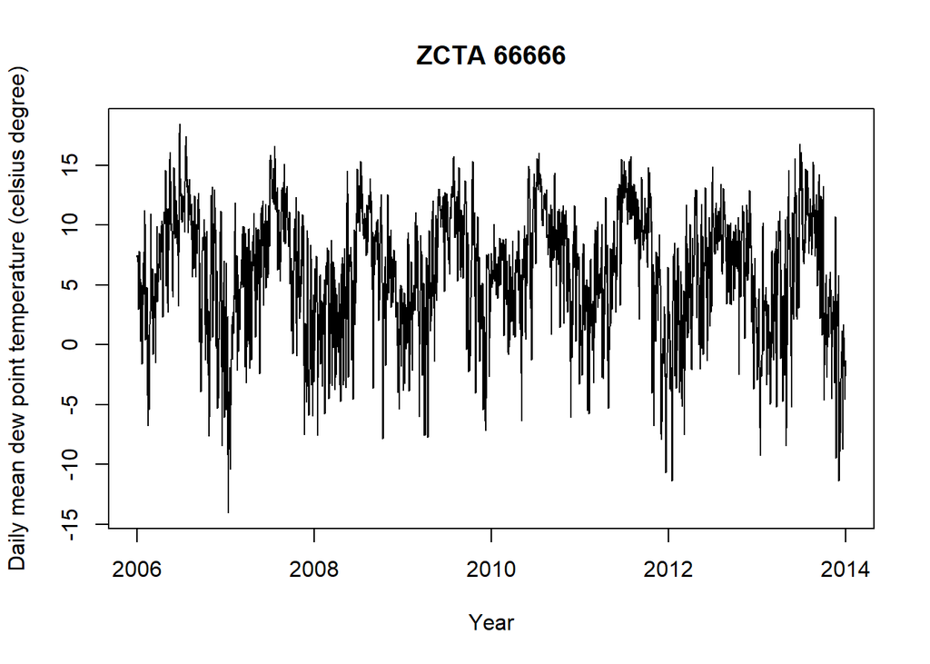

```r
print(plot(dt$date, dt$dptp, type="l", main="ZCTA 66666", xlab = "Year", ylab = "Daily mean dew point temperature (celsius degree)"))
```

### Choose the geographical units (ZCTAs) to include in the study

I stated in the begininig that I included 192 ZCTAs in this study but how did I reach this number? Why not include all ZCTAs?  
Since we need to estimate many parameters in our model, it is important to only include geographical units with large enough populations to avoid extensive zeros in the data that might 1) lead to low statistical power to detect any effect; 2) violate the independent outcome assumption in quasi-Poisson model, lead to failure to converge and requires application of zero-inflated quasi-Poisson model.  
In this study I established the criteria for selecting ZCTAs: 1) with a census 2010 population larger than 50000; 2) with acceptable amount of data (50% of every day data) in each year of 2006-2013. Such criteria should be specified a prior.  
Here is a map showing the study area (192 ZCTAs within California). Please ignore the colors.

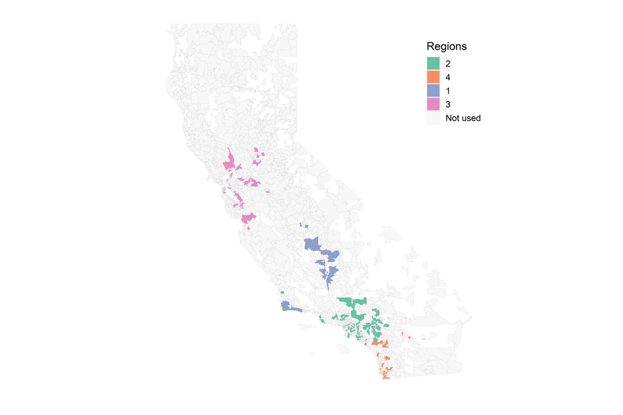

## Quasi-Poisson regression

Here I am showing the example code of running quasi-Poisson regression for one ZCTA. In the real study, I ran this for all 192 ZCTAs.

```r
nyr <- 8 # number of years from 2006 to 2013
ndf <- 8 # number of degree of freedom per year in the spline function to account for long-term temporal trends, chosen based on previous knowledge, e.g., Dominici et al. 2006 and Peng et al. 2006
df.tp <- 3 # number of degree of freedom for temperature terms; normally this is 6 but Califronia has a narrower range of temperature
df.dp <- 3 # number of degree of freedom for dew point temperature terms

f <- glm(cardio_disease ~ offset(log(pop)) + mean_pm25 + ns(day, df = nyr * ndf) + ns(tmpt, df.tp) + ns(dptp, df.dp) + ns(rmtmpt, df.tp) + ns(rmdptp, df.dp), data=dt, family = quasipoisson)
```

Here is how the results would look like.

```r
print(summary(f))
```

```
##
## Call:
## glm(formula = cardio_disease ~ offset(log(pop)) + mean_pm25 +
##     ns(day, df = nyr * ndf) + ns(tmpt, df.tp) + ns(dptp, df.dp) +
##     ns(rmtmpt, df.tp) + ns(rmdptp, df.dp), family = quasipoisson,
##     data = data.raw)
##
## Deviance Residuals:
##     Min       1Q   Median       3Q      Max
## -1.4558  -1.0711  -0.9230   0.5351   2.9676
##
## Coefficients:
##                            Estimate Std. Error t value Pr(>|t|)
## (Intercept)               -9.050398   0.603081 -15.007  < 2e-16 ***
## mean_pm25                  0.004037   0.005819   0.694  0.48786
## ns(day, df = nyr * ndf)1   0.003200   0.512361   0.006  0.99502
## ns(day, df = nyr * ndf)2   0.481608   0.683723   0.704  0.48125
## ns(day, df = nyr * ndf)3  -0.013374   0.615823  -0.022  0.98268
## ns(day, df = nyr * ndf)4  -0.248517   0.664750  -0.374  0.70854
## ns(day, df = nyr * ndf)5   0.674598   0.615122   1.097  0.27287
## ns(day, df = nyr * ndf)6   0.277265   0.601709   0.461  0.64498
## ns(day, df = nyr * ndf)7  -0.068985   0.638072  -0.108  0.91391
## ns(day, df = nyr * ndf)8   0.358363   0.625633   0.573  0.56682
## ns(day, df = nyr * ndf)9  -0.461923   0.650490  -0.710  0.47769
## ns(day, df = nyr * ndf)10  0.759556   0.615844   1.233  0.21755
## ns(day, df = nyr * ndf)11  0.270907   0.627394   0.432  0.66592
## ns(day, df = nyr * ndf)12 -0.367481   0.662554  -0.555  0.57918
## ns(day, df = nyr * ndf)13  0.383286   0.622071   0.616  0.53785
## ns(day, df = nyr * ndf)14  0.174156   0.601424   0.290  0.77216
## ns(day, df = nyr * ndf)15  0.679739   0.592293   1.148  0.25121
## ns(day, df = nyr * ndf)16  0.111087   0.601646   0.185  0.85353
## ns(day, df = nyr * ndf)17  0.272677   0.611871   0.446  0.65589
## ns(day, df = nyr * ndf)18  0.511499   0.639979   0.799  0.42422
## ns(day, df = nyr * ndf)19 -0.420642   0.660250  -0.637  0.52411
## ns(day, df = nyr * ndf)20  0.141954   0.641537   0.221  0.82490
## ns(day, df = nyr * ndf)21  0.475514   0.625261   0.761  0.44702
## ns(day, df = nyr * ndf)22  0.183157   0.578237   0.317  0.75146
## ns(day, df = nyr * ndf)23  0.940270   0.581689   1.616  0.10611
## ns(day, df = nyr * ndf)24  0.080880   0.592173   0.137  0.89137
## ns(day, df = nyr * ndf)25  0.273029   0.607906   0.449  0.65337
```

[output cut: 47 more lines]

```
## ns(rmtmpt, df.tp)3        -0.124095   0.375525  -0.330  0.74108
## ns(rmdptp, df.dp)1         0.359061   0.227745   1.577  0.11500
## ns(rmdptp, df.dp)2         1.105396   0.782711   1.412  0.15798
## ns(rmdptp, df.dp)3         0.821401   0.308888   2.659  0.00788 **
## ---
## Signif. codes:  0 '***' 0.001 '**' 0.01 '*' 0.05 '.' 0.1 ' ' 1
##
## (Dispersion parameter for quasipoisson family taken to be 0.9951502)
##
##     Null deviance: 3072.1  on 2913  degrees of freedom
## Residual deviance: 2988.7  on 2836  degrees of freedom
##   (8 observations deleted due to missingness)
## AIC: NA
##
## Number of Fisher Scoring iterations: 5
```

```r
foo <- data.frame(df = ndf,
                  beta = summary(f)$coefficients["mean_pm25", 1],
                  se = summary(f)$coefficients["mean_pm25", 2],
                  dispersion = summary(f)$dispersion)

foo$est <- exp(foo$beta*10)
foo$ll <- exp((foo$beta - 1.96 * foo$se)*10)
foo$ul <- exp((foo$beta + 1.96 * foo$se)*10)
print(foo[, c("est", "ll", "ul")]) ## Rate ratio per 10 unit increase in PM2.5
```

```
##        est        ll       ul
## 1 1.041201 0.9289651 1.166997
```

## Results pooling

After conducting ZCTA specific analysis, we need to pool results across the geographical units to incorporate information from all locations to improve the precision of our estimates.  
For the example study, we read in Poison regression results from all 192 ZCTAs to aggregate them across using both the *tlnise* package and the *mvmeta* package. The former employs a Bayesian hierarchical model with normal approximation of estimates from quasi-Poisson model. The latter employs meta regression with random intercept for each municipal. Results are similar between the two methods. Both method could incorporate consideration of effect modification (*w* in tlnise and add variables for formula in meta).

Here is how the ZCTA specific results look like:

```r
print(head(foo))
```

```
##    ZCTA5          beta          se dispersion
## 1: 90001 -0.0003210042 0.005835466  0.9810371
## 2: 90002  0.0179955964 0.006067146  1.0330417
## 3: 90003  0.0003305588 0.005753451  0.9925603
## 4: 90004  0.0117287441 0.005796138  0.9636048
## 5: 90006 -0.0073240804 0.006695577  0.9920503
## 6: 90011  0.0034151015 0.005176645  0.9676608
```

Here is the pooling of results using two methods.

```r
### meta-regression
out.m1 <- mvmeta(foo$beta, S = (foo$se)^2, method="reml")
temp <- c(exp(coef(out.m1)), exp(coef(out.m1) - 1.96*sqrt(vcov(out.m1))),  exp(coef(out.m1) + 1.96*sqrt(vcov(out.m1))))
names(temp) <- c("Estimation", "Lower limit for 95% CI", "Upper limit for 95% CI")
print(temp)
```

```
##             Estimation Lower limit for 95% CI Upper limit for 95% CI
##               1.001750               1.000936               1.002564
```

```r
## Bayesian hierarchical model--see details in Everson and Morris 2000
out <- tlnise(Y = foo$beta, V = (foo$se)^2, w = rep(1, nrow(foo)), seed=1234, maxiter = 5000, prnt = FALSE) ## I set w=1 for all ZCTAs, which could be replaced by community effect modifiers
## Estimate and 95% CI of regional mean using posterior mean and SD for stage-two gamma
temp <- c(exp(out$gamma[, "est"]), exp(out$gamma[, "est"] - 1.96*out$gamma[, "se"]), exp(out$gamma[, "est"] + 1.96*out$gamma[, "se"]))
names(temp) <- c("Estimation", "Lower limit for 95% CI", "Upper limit for 95% CI")
print(temp)
```

```
##             Estimation Lower limit for 95% CI Upper limit for 95% CI
##               1.001802               1.000935               1.002670
```

```r
## below I estimated the 95% CI using random pulls from the posterior distribution
## this is useful when more complicated transformations are needed
gs <- tlnise:::sampleGamma(out, V = (foo$se)^2, Y = foo$beta) ## generate samples of gammastar, Dstar from equation (14) of Everson & Morris
sampsGamma <- tlnise:::drawSample0(gs, n=10000)
## Estimate and 95% CI of regional mean using random pulls from posterior distribution
temp <- c(exp(mean(sampsGamma)), exp(quantile(sampsGamma, probs = c(0.025, 0.975))))
names(temp) <- c("Estimation", "Lower limit for 95% CI", "Upper limit for 95% CI")
print(temp)
```

```
##             Estimation Lower limit for 95% CI Upper limit for 95% CI
##               1.001797               1.000917               1.002690
```

## Sensitivity analysis

When we are only interested in one ZCTA, we could conduct sensitivity analyses as below. However, most of the time (including in the example study), we are interested in a pooled results across multiple geographical units and the sensitivity analyses are done for pooled results for all units. I am including the sensitivity analysis with one ZCTA data here for simplicity.

### Try different degree of freedom for long-term and seaonal trend

Here I tried to pick the appropriate degree of freedom by comparing the RR estimated using different df. Alternatively, we could choose a df based on previous knowledge or comparing Akaike Information Criterion of models with different df (extraction of AIC is not straightforward in quisi-Poisson model though). Please see Peng et al. 2006 for more details on model choices.

```r
nyr <- 8 # number of years from 2006 to 2013
df.tp <- 6 # number of degree of freedom for temperature terms
df.dp <- 3 # number of degree of freedom for dew point temperature terms

bar <- numeric()
for (ndf in c(1:20)) { ## use 1 to 20 degree of freedom per year
  f <- glm(cardio_disease ~ offset(log(pop)) + mean_pm25 + ns(day, df = nyr * ndf) + ns(tmpt, df.tp) + ns(dptp, df.dp) + ns(rmtmpt, df.tp) + ns(rmdptp, df.dp), data=dt, family = quasipoisson)
  foo <- data.frame(df = ndf,
                  beta = summary(f)$coefficients["mean_pm25", 1],
                  se = summary(f)$coefficients["mean_pm25", 2],
                  dispersion = summary(f)$dispersion)
  foo$est <- exp(foo$beta*10)
  foo$ll <- exp((foo$beta - 1.96 * foo$se)*10)
  foo$ul <- exp((foo$beta + 1.96 * foo$se)*10)
  bar <- rbind(bar, foo)
}
```

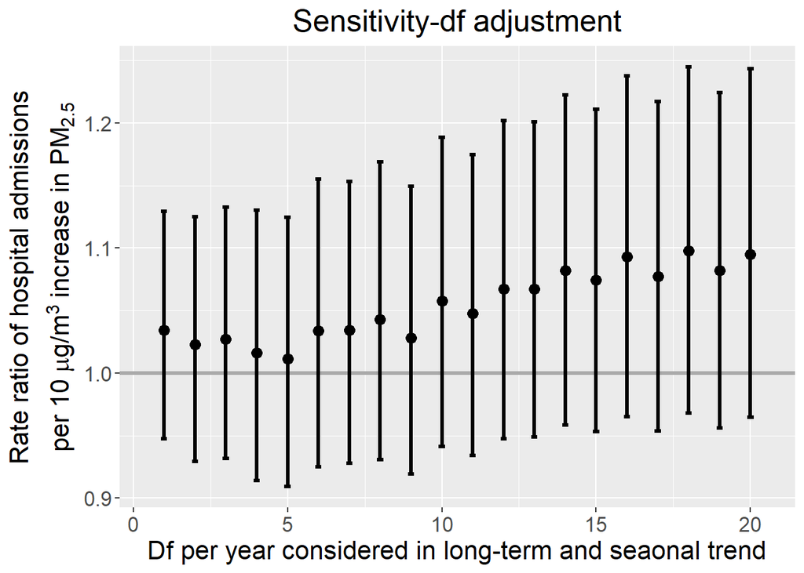

```r
print(ggplot(bar, aes(y=est, x=df, ymax=ul, ymin=ll)) +
          geom_hline(yintercept = 1, col="darkgrey", size=1.2) +
          geom_point(position=position_dodge(width=0.9), size=3) +
        geom_errorbar(position=position_dodge(width=0.9), width=0.2, size=1.2) +
          scale_color_brewer(palette = "Set2") +
          labs(title="Sensitivity-df adjustment", x="Df per year considered in long-term and seaonal trend",
               y=expression(atop("Rate ratio of hospital admissions",
                                 "per 10"~mu*"g/m"^3~"increase in PM"[2.5]))) +
          theme(text = element_text(size=16), plot.title = element_text(hjust = 0.5)))
```

### Try different lag structures

I created $PM_{2.5}$ with one day lag (*mean_pm25l1*) and moving average of $PM_{2.5}$ in the same day and previous two days (*mean_pm25m02*). I also created distributed lag of $PM_{2.5}$ (*mean_pm25d06*) considering lag effect for up to 7 days with two internal knots placed at corresponding quantiles (33% and 66%). I did not show the results here but running a quasi-Poisson model with these exposure metrics will produce corresponding effect estimates.

```r
## create single day exposure with one day lag (previous day exposure)
dt[, mean_pm25l1 := shift(dt$mean_pm25, n = 1, fill = NA, type = "lag")]

## create moving average of current to previous two days (72 hours)
dt[, mean_pm25m02:= frollapply(dt$mean_pm25, n=3, FUN=mean, fill=NA, align="right")]

## below I created a distributed lag model
arglag <- list(fun="ns", range=0:6, int.knots=2) # specify variables for constrained distributed lag
cc <- ns(arglag$range, df=arglag$int.knots+1+1, intercept = TRUE)
temp.lag <- sapply(arglag$range, function(a)
  shift(dt$mean_pm25, n = a, fill = NA, type = "lag")
  # tsModel::Lag(dt$mean_pm2, a) # this also works and is easy to add a by subgroup statement if needed
  )
mean_pm25d06 <- temp.lag %*% cc
dt <- cbind(dt, mean_pm25d06)
names(dt)[(ncol(dt)-3):ncol(dt)] <- paste("mean_pm25d06", 1:4, sep="_")
```

Here is a glimpse of the newly created exposure metrics:

```r
print(dt[1:10, ])
```

```
##           date  zcta  pop cardio_disease mean_pm25   tmpt dptp day dow
##  1: 2006-01-01 66666 3999              0  5.292165  9.845 7.34   1   0
##  2: 2006-01-02 66666 3999              0  6.919871  8.911 7.49   2   1
##  3: 2006-01-03 66666 3999              0 10.252720  9.305 6.98   3   2
##  4: 2006-01-04 66666 3999              0  9.627160 10.525 7.34   4   3
##  5: 2006-01-05 66666 3999              0 18.365769 11.797 6.97   5   4
##  6: 2006-01-06 66666 3999              0 20.075196 10.573 7.15   6   5
##  7: 2006-01-07 66666 3999              0  9.256961 10.852 7.47   7   6
##  8: 2006-01-08 66666 3999              0 18.092236  8.465 2.95   8   0
##  9: 2006-01-09 66666 3999              0 25.841981  8.041 3.82   9   1
## 10: 2006-01-10 66666 3999              0 16.504856  9.378 6.56  10   2
##        rmtmpt   rmdptp mean_pm25l1 mean_pm25m02 mean_pm25d06_1 mean_pm25d06_2
##  1:        NA       NA          NA           NA             NA             NA
##  2:        NA       NA    5.292165           NA             NA             NA
##  3:        NA       NA    6.919871     7.488252             NA             NA
```

[output cut: 18 more lines]

## References

1. Dominici F, Peng RD, Bell ML, et al. Fine particulate air pollution and hospital admission for cardiovascular and respiratory diseases. JAMA. 2006;295(10):1127-1134. doi:10.1001/jama.295.10.1127
2. Peng RD, Dominici F, Louis TA. Model choice in time series studies of air pollution and mortality. J R Stat Soc Ser A Stat Soc. 2006;169(2):179-203. doi:10.1111/j.1467-985X.2006.00410.x
3. Everson PJ, Morris CN. Inference for multivariate normal hierarchical models. J R Stat Soc Series B Stat Methodol. 2000;62(2):399-412. doi:10.1111/1467-9868.00239